# Diversity & Movement in the Sonoran Desert Bark Beetle (*Araptus attenuata*).

# Introduction

Plant-insect species pairs from the Baja California peninsula, together with an adjacent section of the Sonoran Desert on mainland Mexico, provide useful models for examining the degree to which constraints imposed by biotic interactions may influence a species’ capacity to track the changing distribution of habitats. This is because the dynamic geological and environmental history of this landscape seems to have impacted the genetic structure of plants and animals in different ways (e.g. Riddle et al. 2000; Garrick et al. 2009a), such that the influence of host plant phylogeographical history is may put constraints upon its obligate insect parasite or pollinator species.

Given their life histories, plants may track changing local environmental conditions more closely than animals do because their phenologies and physiological tolerances can be strongly tied to precipitation or the frequency and severity of winter frosts. Macrofossils preserved in packrat middens indicate early- to mid-Holocene northward range shifts of floristic communities in the region. Overall, patterns of diversity in many cacti species in this region indicate that the southern Cape Region served as an important refuge for frost intolerant taxa during Pleistocene glacial cycles, perhaps owing to its low latitude and deeply dissected, heterogeneous topography. Interestingly, this *a priori* expectation of northward range expansion contrasts sharply with observed patterns of genetic variation in a long-lived Sonoran Desert euphorb (*Euphorbia lomelii* V.W. Steinm., synon. *Pedilanthus macrocarpus*), for which there is strong evidence for southward range expansion following emergence from refugia along the Sea of Cortez.

In this manuscript, we examine the extent to which the distribution of the host plant, *Euphorbia lomelii* (Euphorbiaceae), influences the genetic structure of its obligate bark beetle, *Araptus attenuata* (Curculionidae). Previous work on this beetle species has shown broad scale phylogeographic patterning influenced by both Pleistocene refugia as well as post-pleistocene range expansion. Moreover, this group of animals has been genetically shown to have at least three different, cryptic, species, some of which are found in sympatry (at the same location). To better understand the factors influencing connectivity between populations and the extent to which intervening environment influences genetic structure, we address the following questions:

1. Is there any any difference between in overall genetic diversity of the three identified cryptic species found in the Sonoran Desert? If so, is there any indication that the size of the species range is related to observed genetic diversity?
2. Are there any indications that environmental conditions or position along the Baja California Peninsula are influencing observed genetic diversity?
3. To what extent do niche suitability of the host plant and local environmental conditions influence the relative ratio of male and female found at a locale?

Understanding the ecological, genetic, and spatial drivers of diversity and sex-biased dispersal may be able to provide valuable insights into the this enigmatic desert beetle.

# Methods

## Study Species

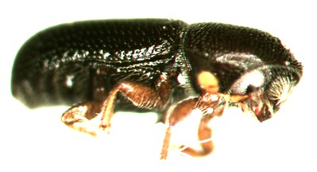

Figure 1: The sonoran desert bark beetle *Araptus attenuatus*.

The bark beetle, *Araptus attenuatus* (Figure 1) is an endemic bark beetle found only within the Sonoran desert geo-region. At present, there are three known cryptic species described for this taxa (Dyer unpub.) inhabiting populations throughout peninsular Baja California and limited locations on mainland Mexico. To date, all samples of this species group have been found with in association with the plant *Euphorbia lomelii* (Figure 2). Young males colonize recently senescent stems on the host plant and release mating pheromones. Female individuals who establish form breeding colonies. Along the Baja California Peninsula, when both species are found at the same sampling location, only one of the species is found in each plant consistent with the hypothesis of competitive exclusion of a limited ecological resources.

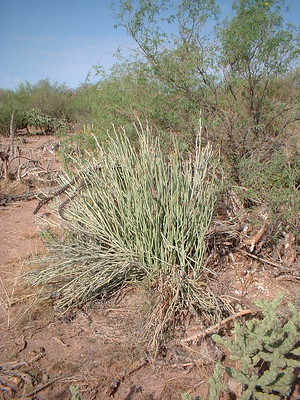

Figure 2: The host plant for *Araptus attenuatus*, the desert euphorb, *Euphorbia lomelii*.

## Spatial Sampling

Summaries of minimum, mean, and maximum numbers of males and females are provided in tabular format, though subsequent analyses standardize local densities by creating a ratio of male:female individuals at each locale. Host plant tissue was also collected, frozen, and returned to VCU. Total genomic DNA was extracted from each individual as well as their host plant. All animals were genotyped and estimates of Allelic Diversity were derived for each sampling location for all three species.

## Genetic Diversity

Finally, within the larger group of animals designated as *Peninsula*—since it is the most widely distributed group—we examined the extent to which the location on the peninsula (measured along degrees latitude of the site), estimated habitat suitability, and estimated values of both temperature and precipitation (extracted from raster data provided by WorldClim) influenced genetic diversity. For the local temperature and environmental measurements, we tested for colinearity—a condition where predictor variables with a high degree of correlation should not be used in regression models. Our criteria for colinearity was $\rho \ge 0.60$, and if two variables significantly exceeded this threshold, one of them was removed from consideration in regression model development. In the case of multiple potential models, we used Akaike’s Information Criteria (AIC) to identify the best (or set of equally informative) models describing the observed values of diversity for bark beetle.

## Site-Specific Environmental Conditions

Several bioclimactic variables were used to construct an ecological niche envelope for the host plant, *Euphorbia lomelii*. From this reconstruction, we estimate the relative *suitability* of the location for as a surrogate for examining genetic diversity and sex ratio bias in the bark beetle. Along with the local site-specific measures for temperature and precipitation, we determined if beetle sex ratio was influenced by some combination of host-plant suitability and local environmental features. As above, we only used those predictors that were not found to be colinear and identified the best subset of potential models using AIC.

# Results

## Site-Sepcific Environmental Conditions